# Group-3 : Capstope Project-Home_Credit_Default_Risk_Prediction

Amiya Ranjan Sahoo, Jeffrey Zhang, Gaurav Mishra , Robert Sheehy

2025-10-27

*Introduction:-*

The Home Credit Default Risk project aims to develop a predictive model that assesses the likelihood of a loan applicant defaulting on repayment. Home Credit, a consumer-finance company, provides loans to clients with limited or no credit history. By accurately predicting default probability, the company can reduce financial risk while maintaining loan accessibility for underbanked populations.

The original dataset contains over 600,000 client records across multiple linked tables (application, credit history, bureau, and payment data). After extensive preprocessing—handling missing values, removing anomalies, and normalizing features—the cleaned training dataset comprises approximately 307,000 clients, each described by demographic, financial, and behavioral attributes. The target variable TARGET indicates whether a client repaid (0) or defaulted (1) on their loan.

This analysis follows the full CRISP-DM process—data understanding, preparation, modeling, and evaluation—with emphasis on predictive modeling. After comprehensive data cleaning and feature engineering, multiple algorithms are compared: • Model 1: Penalized Logistic Regression (glmnet) • Model 2: Decision Tree (CART) • Model 3: Random Forest (ranger) • Model 4: Gradient Boosting (XGBoost)

Model performance is evaluated on a stratified 70 / 30 train–validation split using 5-fold cross-validation. Metrics include AUC, Accuracy, Precision, Recall, and F1 Score. The ultimate objective is to identify the model that not only outperforms the majority-class benchmark (~92 % accuracy but no discrimination) but also provides stable, interpretable predictions that can support risk-aware lending decisions.

# 1 .Code Chunk 1 — Load Required Libraries

```r
knitr::opts_chunk$set(echo = TRUE)

## ---- load-libraries ----
# Core modeling workflow per Kuhn & Johnson
library(tidyverse)     # data manipulation and ggplot2
library(caret)         # data preprocessing and resampling
library(recipes)       # feature engineering pipeline
library(data.table)    # fast I/O for large CSVs
library(skimr)         # quick summaries
library(janitor)       # clean column names
library(gt)            # table display
library(GGally)        # correlation and pair plots
library(ggplot2)       # visualization
library(forcats)       # factor handling
library(rpart.plot)
set.seed(123)          # reproducibility
```

# 2 .Code Chunk 2 — Load and Inspect the Training Dataset

This code chunk imports the main training dataset (application_train.csv) using fread() for fast and efficient loading, then standardizes column names with clean_names(). It provides an initial overview of the dataset through structure, dimensions, and a preview of the first few rows. Basic summary statistics and data types are examined to understand the variable composition and detect any immediate data quality issues before preprocessing.

```r
## ---- load-data ----
# Use fread() for efficiency
app_train <- fread("application_train.csv") |> clean_names()

# Basic structure check
dim(app_train)
```

```
## [1] 307511    122
```

```r
str(app_train[, 1:10])
```

```
## Classes 'data.table' and 'data.frame':   307511 obs. of  10 variables:
##  $ sk_id_curr        : int  100002 100003 100004 100006 100007 100008 100009 100010 100011 100012 ...
##  $ target            : int  1 0 0 0 0 0 0 0 0 0 ...
##  $ name_contract_type: chr  "Cash loans" "Cash loans" "Revolving loans" "Cash loans" ...
##  $ code_gender       : chr  "M" "F" "M" "F" ...
##  $ flag_own_car      : chr  "N" "N" "Y" "N" ...
##  $ flag_own_realty   : chr  "Y" "N" "Y" "Y" ...
##  $ cnt_children      : int  0 0 0 0 0 0 1 0 0 0 ...
##  $ amt_income_total  : num  202500 270000 67500 135000 121500 ...
##  $ amt_credit        : num  406598 1293502 135000 312682 513000 ...
##  $ amt_annuity       : num  24700 35698 6750 29686 21866 ...
##  - attr(*, ".internal.selfref")=<externalptr>
```

```r
gt(as.data.frame(head(app_train, 10)))
```

| sk_id_curr | target | name_contract_type | code_gender | flag_own_car | flag_own_realty | cnt_children | amt_income_total | amt_credit | amt_annuity | amt_goods_price | name_type_suite | name_income_type | name_education_type | name_family_status | name_housing_type | region_population_relative | days_birth | days_employed | days_registration | days_id_publish | own_car_age | flag_mobil | flag_emp_phone | flag_work_phone | flag_cont_mobile | flag_phone | flag_email | occupation_type | cnt_fam_members | … |
| --- | --- | --- | --- | --- | --- | --- | --- | --- | --- | --- | --- | --- | --- | --- | --- | --- | --- | --- | --- | --- | --- | --- | --- | --- | --- | --- | --- | --- | --- | --- |
| 100002 | 1 | Cash loans | M | N | Y | 0 | 202500 | 406597.5 | 24700.5 | 351000 | Unaccompanied | Working | Secondary / secondary special | Single / not married | House / apartment | 0.018801 | -9461 | -637 | -3648 | -2120 | NA | 1 | 1 | 0 | 1 | 1 | 0 | Laborers | 1 | … |
| 100003 | 0 | Cash loans | F | N | N | 0 | 270000 | 1293502.5 | 35698.5 | 1129500 | Family | State servant | Higher education | Married | House / apartment | 0.003541 | -16765 | -1188 | -1186 | -291 | NA | 1 | 1 | 0 | 1 | 1 | 0 | Core staff | 2 | … |
| 100004 | 0 | Revolving loans | M | Y | Y | 0 | 67500 | 135000.0 | 6750.0 | 135000 | Unaccompanied | Working | Secondary / secondary special | Single / not married | House / apartment | 0.010032 | -19046 | -225 | -4260 | -2531 | 26 | 1 | 1 | 1 | 1 | 1 | 0 | Laborers | 1 | … |
| 100006 | 0 | Cash loans | F | N | Y | 0 | 135000 | 312682.5 | 29686.5 | 297000 | Unaccompanied | Working | Secondary / secondary special | Civil marriage | House / apartment | 0.008019 | -19005 | -3039 | -9833 | -2437 | NA | 1 | 1 | 0 | 1 | 0 | 0 | Laborers | 2 | … |
| 100007 | 0 | Cash loans | M | N | Y | 0 | 121500 | 513000.0 | 21865.5 | 513000 | Unaccompanied | Working | Secondary / secondary special | Single / not married | House / apartment | 0.028663 | -19932 | -3038 | -4311 | -3458 | NA | 1 | 1 | 0 | 1 | 0 | 0 | Core staff | 1 | … |
| 100008 | 0 | Cash loans | M | N | Y | 0 | 99000 | 490495.5 | 27517.5 | 454500 | Spouse, partner | State servant | Secondary / secondary special | Married | House / apartment | 0.035792 | -16941 | -1588 | -4970 | -477 | NA | 1 | 1 | 1 | 1 | 1 | 0 | Laborers | 2 | … |
| 100009 | 0 | Cash loans | F | Y | Y | 1 | 171000 | 1560726.0 | 41301.0 | 1395000 | Unaccompanied | Commercial associate | Higher education | Married | House / apartment | 0.035792 | -13778 | -3130 | -1213 | -619 | 17 | 1 | 1 | 0 | 1 | 1 | 0 | Accountants | 3 | … |
| 100010 | 0 | Cash loans | M | Y | Y | 0 | 360000 | 1530000.0 | 42075.0 | 1530000 | Unaccompanied | State servant | Higher education | Married | House / apartment | 0.003122 | -18850 | -449 | -4597 | -2379 | 8 | 1 | 1 | 1 | 1 | 0 | 0 | Managers | 2 | … |
| 100011 | 0 | Cash loans | F | N | Y | 0 | 112500 | 1019610.0 | 33826.5 | 913500 | Children | Pensioner | Secondary / secondary special | Married | House / apartment | 0.018634 | -20099 | 365243 | -7427 | -3514 | NA | 1 | 0 | 0 | 1 | 0 | 0 |  | 2 | … |
| 100012 | 0 | Revolving loans | M | N | Y | 0 | 135000 | 405000.0 | 20250.0 | 405000 | Unaccompanied | Working | Secondary / secondary special | Single / not married | House / apartment | 0.019689 | -14469 | -2019 | -14437 | -3992 | NA | 1 | 1 | 0 | 1 | 0 | 0 | Laborers | 1 | … |

```r
# Quick summary per Kuhn & Johnson step 1: "Understand data characteristics"
skim(app_train)
```

Data summary

| Name | app_train |
| --- | --- |
| Number of rows | 307511 |
| Number of columns | 122 |
| Key | NULL |
| _______________________ |  |
| Column type frequency: |  |
| character | 16 |
| numeric | 106 |
| ________________________ |  |
| Group variables | None |

**Variable type: character**

| skim_variable | n_missing | complete_rate | min | max | empty | n_unique | whitespace |
| --- | --- | --- | --- | --- | --- | --- | --- |
| name_contract_type | 0 | 1 | 10 | 15 | 0 | 2 | 0 |
| code_gender | 0 | 1 | 1 | 3 | 0 | 3 | 0 |
| flag_own_car | 0 | 1 | 1 | 1 | 0 | 2 | 0 |
| flag_own_realty | 0 | 1 | 1 | 1 | 0 | 2 | 0 |
| name_type_suite | 0 | 1 | 0 | 15 | 1292 | 8 | 0 |
| name_income_type | 0 | 1 | 7 | 20 | 0 | 8 | 0 |
| name_education_type | 0 | 1 | 15 | 29 | 0 | 5 | 0 |
| name_family_status | 0 | 1 | 5 | 20 | 0 | 6 | 0 |
| name_housing_type | 0 | 1 | 12 | 19 | 0 | 6 | 0 |
| occupation_type | 0 | 1 | 0 | 21 | 96391 | 19 | 0 |
| weekday_appr_process_start | 0 | 1 | 6 | 9 | 0 | 7 | 0 |
| organization_type | 0 | 1 | 3 | 22 | 0 | 58 | 0 |
| fondkapremont_mode | 0 | 1 | 0 | 21 | 210295 | 5 | 0 |
| housetype_mode | 0 | 1 | 0 | 16 | 154297 | 4 | 0 |
| wallsmaterial_mode | 0 | 1 | 0 | 12 | 156341 | 8 | 0 |
| emergencystate_mode | 0 | 1 | 0 | 3 | 145755 | 3 | 0 |

**Variable type: numeric**

| skim_variable | n_missing | complete_rate | mean | sd | p0 | p25 | p50 | p75 | p100 | hist |
| --- | --- | --- | --- | --- | --- | --- | --- | --- | --- | --- |
| sk_id_curr | 0 | 1.00 | 278180.52 | 102790.18 | 100002.00 | 189145.50 | 278202.00 | 367142.50 | 456255.00 | ▇▇▇▇▇ |
| target | 0 | 1.00 | 0.08 | 0.27 | 0.00 | 0.00 | 0.00 | 0.00 | 1.00 | ▇▁▁▁▁ |
| cnt_children | 0 | 1.00 | 0.42 | 0.72 | 0.00 | 0.00 | 0.00 | 1.00 | 19.00 | ▇▁▁▁▁ |
| amt_income_total | 0 | 1.00 | 168797.92 | 237123.15 | 25650.00 | 112500.00 | 147150.00 | 202500.00 | 117000000.00 | ▇▁▁▁▁ |
| amt_credit | 0 | 1.00 | 599026.00 | 402490.78 | 45000.00 | 270000.00 | 513531.00 | 808650.00 | 4050000.00 | ▇▂▁▁▁ |
| amt_annuity | 12 | 1.00 | 27108.57 | 14493.74 | 1615.50 | 16524.00 | 24903.00 | 34596.00 | 258025.50 | ▇▁▁▁▁ |
| amt_goods_price | 278 | 1.00 | 538396.21 | 369446.46 | 40500.00 | 238500.00 | 450000.00 | 679500.00 | 4050000.00 | ▇▂▁▁▁ |
| region_population_relative | 0 | 1.00 | 0.02 | 0.01 | 0.00 | 0.01 | 0.02 | 0.03 | 0.07 | ▇▇▃▁▁ |
| days_birth | 0 | 1.00 | -16037.00 | 4363.99 | -25229.00 | -19682.00 | -15750.00 | -12413.00 | -7489.00 | ▃▆▇▇▅ |
| days_employed | 0 | 1.00 | 63815.05 | 141275.77 | -17912.00 | -2760.00 | -1213.00 | -289.00 | 365243.00 | ▇▁▁▁▂ |
| days_registration | 0 | 1.00 | -4986.12 | 3522.89 | -24672.00 | -7479.50 | -4504.00 | -2010.00 | 0.00 | ▁▁▂▅▇ |
| days_id_publish | 0 | 1.00 | -2994.20 | 1509.45 | -7197.00 | -4299.00 | -3254.00 | -1720.00 | 0.00 | ▁▆▇▆▅ |
| own_car_age | 202929 | 0.34 | 12.06 | 11.94 | 0.00 | 5.00 | 9.00 | 15.00 | 91.00 | ▇▁▁▁▁ |
| flag_mobil | 0 | 1.00 | 1.00 | 0.00 | 0.00 | 1.00 | 1.00 | 1.00 | 1.00 | ▁▁▁▁▇ |
| flag_emp_phone | 0 | 1.00 | 0.82 | 0.38 | 0.00 | 1.00 | 1.00 | 1.00 | 1.00 | ▂▁▁▁▇ |
| flag_work_phone | 0 | 1.00 | 0.20 | 0.40 | 0.00 | 0.00 | 0.00 | 0.00 | 1.00 | ▇▁▁▁▂ |
| flag_cont_mobile | 0 | 1.00 | 1.00 | 0.04 | 0.00 | 1.00 | 1.00 | 1.00 | 1.00 | ▁▁▁▁▇ |
| flag_phone | 0 | 1.00 | 0.28 | 0.45 | 0.00 | 0.00 | 0.00 | 1.00 | 1.00 | ▇▁▁▁▃ |
| flag_email | 0 | 1.00 | 0.06 | 0.23 | 0.00 | 0.00 | 0.00 | 0.00 | 1.00 | ▇▁▁▁▁ |
| cnt_fam_members | 2 | 1.00 | 2.15 | 0.91 | 1.00 | 2.00 | 2.00 | 3.00 | 20.00 | ▇▁▁▁▁ |
| region_rating_client | 0 | 1.00 | 2.05 | 0.51 | 1.00 | 2.00 | 2.00 | 2.00 | 3.00 | ▁▁▇▁▂ |
| region_rating_client_w_city | 0 | 1.00 | 2.03 | 0.50 | 1.00 | 2.00 | 2.00 | 2.00 | 3.00 | ▁▁▇▁▂ |
| hour_appr_process_start | 0 | 1.00 | 12.06 | 3.27 | 0.00 | 10.00 | 12.00 | 14.00 | 23.00 | ▁▃▇▆▁ |
| reg_region_not_live_region | 0 | 1.00 | 0.02 | 0.12 | 0.00 | 0.00 | 0.00 | 0.00 | 1.00 | ▇▁▁▁▁ |
| reg_region_not_work_region | 0 | 1.00 | 0.05 | 0.22 | 0.00 | 0.00 | 0.00 | 0.00 | 1.00 | ▇▁▁▁▁ |
| live_region_not_work_region | 0 | 1.00 | 0.04 | 0.20 | 0.00 | 0.00 | 0.00 | 0.00 | 1.00 | ▇▁▁▁▁ |
| reg_city_not_live_city | 0 | 1.00 | 0.08 | 0.27 | 0.00 | 0.00 | 0.00 | 0.00 | 1.00 | ▇▁▁▁▁ |
| reg_city_not_work_city | 0 | 1.00 | 0.23 | 0.42 | 0.00 | 0.00 | 0.00 | 0.00 | 1.00 | ▇▁▁▁▂ |
| live_city_not_work_city | 0 | 1.00 | 0.18 | 0.38 | 0.00 | 0.00 | 0.00 | 0.00 | 1.00 | ▇▁▁▁▂ |
| ext_source_1 | 173378 | 0.44 | 0.50 | 0.21 | 0.01 | 0.33 | 0.51 | 0.68 | 0.96 | ▂▇▇▇▃ |

[output cut: 76 more lines]

# 3 .Code Chunk 3 — Basic hygiene and anomaly fixes

What this does • Validates core columns exist. Fail fast if not. • Encodes target as a factor for classification. • Replaces the sentinel 365243 in days_employed with NA. This is a documented anomaly. • Creates leak-safe features: age_years from days_birth, emp_years from days_employed. These are standard transforms used in the book’s preprocessing stage.

```r
## ---- clean-basics ----
# prerequisites: app_train from previous chunk, names are snake_case

# 1) assert required columns exist
stopifnot(all(c("sk_id_curr","target","days_birth","days_employed") %in% names(app_train)))

# 2) target to 2-level factor (0 = Repaid, 1 = Default)
app_train <- app_train |>
  dplyr::mutate(target = factor(target, levels = c(0,1)))

# 3) fix known sentinel in days_employed (365243 means "missing")
app_train <- app_train |>
  dplyr::mutate(days_employed = dplyr::na_if(days_employed, 365243))

# 4) safe human-readable derivatives (no leakage)
app_train <- app_train |>
  dplyr::mutate(
    age_years = -days_birth/365.25,
    emp_years = dplyr::if_else(!is.na(days_employed), -days_employed/365.25, NA_real_)
  )
```

## 3.1 .Check structure and summary of key columns and Inspect missing values and a few rows

```r
str(app_train[, c("target", "days_birth", "days_employed", "age_years", "emp_years")])
```

```
## Classes 'data.table' and 'data.frame':   307511 obs. of  5 variables:
##  $ target       : Factor w/ 2 levels "0","1": 2 1 1 1 1 1 1 1 1 1 ...
##  $ days_birth   : int  -9461 -16765 -19046 -19005 -19932 -16941 -13778 -18850 -20099 -14469 ...
##  $ days_employed: int  -637 -1188 -225 -3039 -3038 -1588 -3130 -449 NA -2019 ...
##  $ age_years    : num  25.9 45.9 52.1 52 54.6 ...
##  $ emp_years    : num  1.744 3.253 0.616 8.32 8.318 ...
##  - attr(*, ".internal.selfref")=<externalptr>
```

```r
summary(app_train[, .(days_employed, age_years, emp_years)])
```

```
##  days_employed      age_years       emp_years
##  Min.   :-17912   Min.   :20.50   Min.   : 0.000
##  1st Qu.: -3175   1st Qu.:33.98   1st Qu.: 2.100
##  Median : -1648   Median :43.12   Median : 4.512
##  Mean   : -2384   Mean   :43.91   Mean   : 6.527
##  3rd Qu.:  -767   3rd Qu.:53.89   3rd Qu.: 8.693
##  Max.   :     0   Max.   :69.07   Max.   :49.040
##  NA's   :55374                    NA's   :55374
```

```r
head(app_train[, .(sk_id_curr, target, age_years, emp_years)])
```

```
##    sk_id_curr target age_years emp_years
##         <int> <fctr>     <num>     <num>
## 1:     100002      1  25.90281 1.7440110
## 2:     100003      0  45.90007 3.2525667
## 3:     100004      0  52.14511 0.6160164
## 4:     100006      0  52.03285 8.3203285
## 5:     100007      0  54.57084 8.3175907
## 6:     100008      0  46.38193 4.3477070
```

# 4 .Code Chunk 4 — Missingness scan and prune high-NA columns

What it does • Quantifies missingness per variable. • Drops columns with ≥80% NA to reduce noise and leakage risk. • Preserves sparse but useful scores (ext_source_1, ext_source_3) if they exist.

How to check • head(miss_pct, 25) shows the worst offenders. • length(drop_cols) shows count to be removed. • Final line should return character(0).

```r
## ---- missing-scan ----
library(dplyr)

# percent NA per column
miss_pct <- sapply(app_train, function(x) mean(is.na(x))) |> sort(decreasing = TRUE)

# inspect top 25
head(miss_pct, 25)
```

```
##           commonarea_avg          commonarea_mode          commonarea_medi
##                0.6987230                0.6987230                0.6987230
##  nonlivingapartments_avg nonlivingapartments_mode nonlivingapartments_medi
##                0.6943296                0.6943296                0.6943296
##     livingapartments_avg    livingapartments_mode    livingapartments_medi
##                0.6835495                0.6835495                0.6835495
##            floorsmin_avg           floorsmin_mode           floorsmin_medi
##                0.6784863                0.6784863                0.6784863
##          years_build_avg         years_build_mode         years_build_medi
##                0.6649778                0.6649778                0.6649778
##              own_car_age             landarea_avg            landarea_mode
##                0.6599081                0.5937674                0.5937674
##            landarea_medi         basementarea_avg        basementarea_mode
##                0.5937674                0.5851596                0.5851596
##        basementarea_medi             ext_source_1        nonlivingarea_avg
##                0.5851596                0.5638107                0.5517916
##       nonlivingarea_mode
##                0.5517916
```

```r
# drop columns with ≥ 80% NA, except keep key sparse predictors if present
keep_anyway <- intersect(names(app_train), c("ext_source_1","ext_source_3"))
high_na <- names(miss_pct[miss_pct >= 0.80])
drop_cols <- setdiff(high_na, keep_anyway)

length(drop_cols)      # how many to drop
```

```
## [1] 0
```

```r
drop_cols[1:20]        # preview names
```

```
##  [1] NA NA NA NA NA NA NA NA NA NA NA NA NA NA NA NA NA NA NA NA
```

```r
app_train <- app_train |> select(-all_of(drop_cols))

# sanity: confirm removed
intersect(names(app_train), drop_cols)  # should be character(0)
```

```
## character(0)
```

# 5 .Code Chunk 5 — Build the preprocessing recipe

What it does • Excludes sk_id_curr from modeling if present. • Removes zero/near-zero variance columns. • Imputes numerics by median and factors by mode. • Groups rare factor levels into .rare to stabilize. • One-hot encodes factors. • Fixes skew with Yeo–Johnson, then centers and scales numerics. • Drops highly correlated numerics (>|0.90|).

```r
## ---- recipe-prep ----
library(recipes); library(caret)

# target must be factor already (done earlier)
stopifnot(is.factor(app_train$target))

# mark ID so it’s excluded from predictors
has_id <- "sk_id_curr" %in% names(app_train)

rec <- recipe(target ~ ., data = app_train) %>%
  { if (has_id) update_role(., sk_id_curr, new_role = "ID") else . } %>%
  step_zv(all_predictors()) %>%
  step_nzv(all_predictors()) %>%
  step_impute_median(all_numeric_predictors()) %>%
  step_impute_mode(all_nominal_predictors()) %>%
  step_other(all_nominal_predictors(), threshold = 0.01, other = ".rare") %>%
  step_dummy(all_nominal_predictors(), one_hot = TRUE) %>%
  step_YeoJohnson(all_numeric_predictors()) %>%
  step_center(all_numeric_predictors()) %>%
  step_scale(all_numeric_predictors()) %>%
  step_corr(all_numeric_predictors(), threshold = 0.90)

rec_prep   <- prep(rec, training = app_train, verbose = TRUE)
```

```
## oper 1 step zv [training]
## oper 2 step nzv [training]
## oper 3 step impute median [training]
## oper 4 step impute mode [training]
## oper 5 step other [training]
## oper 6 step dummy [training]
## oper 7 step YeoJohnson [training]
## oper 8 step center [training]
## oper 9 step scale [training]
## oper 10 step corr [training]
## The retained training set is ~ 297.98 Mb  in memory.
```

```r
train_clean <- bake(rec_prep, new_data = NULL)
# drop ID column before modeling
train_clean <- dplyr::select(train_clean, -sk_id_curr)

dim(train_clean)
```

```
## [1] 307511    127
```

## 5.1 .Checking the structure of the variables

```r
# columns and types look model-ready
str(train_clean[ , 1:20])
```

```
## tibble [307,511 × 20] (S3: tbl_df/tbl/data.frame)
##  $ cnt_children              : num [1:307511] -0.653 -0.653 -0.653 -0.653 -0.653 ...
##  $ amt_income_total          : num [1:307511] 0.647 1.213 -1.656 -0.175 -0.394 ...
##  $ amt_credit                : num [1:307511] -0.284 1.4954 -1.6483 -0.6357 0.0424 ...
##  $ amt_annuity               : num [1:307511] 0.0269 0.7446 -2.0819 0.3779 -0.1981 ...
##  $ region_population_relative: num [1:307511] -0.149 -1.253 -0.783 -0.929 0.564 ...
##  $ days_birth                : num [1:307511] 1.597 -0.223 -0.717 -0.708 -0.901 ...
##  $ days_employed             : num [1:307511] 0.939 0.336 1.81 -0.708 -0.708 ...
##  $ days_registration         : num [1:307511] 0.17108 1.12255 -0.00709 -1.24507 -0.02134 ...
##  $ days_id_publish           : num [1:307511] 0.554 1.838 0.281 0.343 -0.323 ...
##  $ own_car_age               : num [1:307511] 0.00505 0.00505 2.24493 0.00505 0.00505 ...
##  $ flag_work_phone           : num [1:307511] -0.499 -0.499 2.004 -0.499 -0.499 ...
##  $ flag_phone                : num [1:307511] 1.599 1.599 1.599 -0.625 -0.625 ...
##  $ flag_email                : num [1:307511] -0.245 -0.245 -0.245 -0.245 -0.245 ...
##  $ cnt_fam_members           : num [1:307511] -1.5209 -0.0115 -1.5209 -0.0115 -1.5209 ...
##  $ region_rating_client      : num [1:307511] -0.103 -2.068 -0.103 -0.103 -0.103 ...
##  $ hour_appr_process_start   : num [1:307511] -0.634 -0.328 -0.939 1.515 -0.328 ...
##  $ reg_region_not_work_region: num [1:307511] -0.231 -0.231 -0.231 -0.231 -0.231 ...
##  $ reg_city_not_live_city    : num [1:307511] -0.291 -0.291 -0.291 -0.291 -0.291 ...
##  $ reg_city_not_work_city    : num [1:307511] -0.547 -0.547 -0.547 -0.547 1.827 ...
##  $ live_city_not_work_city   : num [1:307511] -0.468 -0.468 -0.468 -0.468 2.138 ...
```

```r
sum(is.na(train_clean))              # should be 0
```

```
## [1] 0
```

```r
table(train_clean$target)            # factor with 2 levels
```

```
##
##      0      1
## 282686  24825
```

```r
"sk_id_curr" %in% names(train_clean)
```

```
## [1] FALSE
```

## 5.2 .ID is stored in a separate vector if we want to map predictions back:

```r
ids <- app_train$sk_id_curr
```

# 6 .Code Chunk 6 — Save preprocessing artifacts

What it does • Persists the fitted recipe and the cleansed matrix. • Lets you reload the exact preprocessing later.

```r
## ---- save-artifacts ----
saveRDS(rec_prep, "rec_prepared.rds")
data.table::fwrite(train_clean, "train_clean.csv")

file.info("rec_prepared.rds")[, c("size","mtime")]
```

```
##                       size               mtime
## rec_prepared.rds 341227490 2025-10-27 16:14:02
```

```r
file.info("train_clean.csv")[, c("size","mtime")]
```

```
##                      size               mtime
## train_clean.csv 724312583 2025-10-27 16:14:02
```

## 6.1 .Code Chunk — Inspect the cleaned dataset

This code chunk reviews the dataset after all preprocessing and transformation steps have been applied. It verifies that missing values, outliers, and redundant variables have been addressed, and that all predictors are in the correct numeric or factor format. The goal is to confirm that the cleaned dataset is ready for modeling, with consistent structure and no data integrity issues.

```r
## ---- inspect-cleaned ----
library(skimr)
library(gt)

# 1. Dimensions
dim(train_clean)
```

```
## [1] 307511    127
```

```r
# 2. Structure of first few columns
str(train_clean[, 1:20])
```

```
## tibble [307,511 × 20] (S3: tbl_df/tbl/data.frame)
##  $ cnt_children              : num [1:307511] -0.653 -0.653 -0.653 -0.653 -0.653 ...
##  $ amt_income_total          : num [1:307511] 0.647 1.213 -1.656 -0.175 -0.394 ...
##  $ amt_credit                : num [1:307511] -0.284 1.4954 -1.6483 -0.6357 0.0424 ...
##  $ amt_annuity               : num [1:307511] 0.0269 0.7446 -2.0819 0.3779 -0.1981 ...
##  $ region_population_relative: num [1:307511] -0.149 -1.253 -0.783 -0.929 0.564 ...
##  $ days_birth                : num [1:307511] 1.597 -0.223 -0.717 -0.708 -0.901 ...
##  $ days_employed             : num [1:307511] 0.939 0.336 1.81 -0.708 -0.708 ...
##  $ days_registration         : num [1:307511] 0.17108 1.12255 -0.00709 -1.24507 -0.02134 ...
##  $ days_id_publish           : num [1:307511] 0.554 1.838 0.281 0.343 -0.323 ...
##  $ own_car_age               : num [1:307511] 0.00505 0.00505 2.24493 0.00505 0.00505 ...
##  $ flag_work_phone           : num [1:307511] -0.499 -0.499 2.004 -0.499 -0.499 ...
##  $ flag_phone                : num [1:307511] 1.599 1.599 1.599 -0.625 -0.625 ...
##  $ flag_email                : num [1:307511] -0.245 -0.245 -0.245 -0.245 -0.245 ...
##  $ cnt_fam_members           : num [1:307511] -1.5209 -0.0115 -1.5209 -0.0115 -1.5209 ...
##  $ region_rating_client      : num [1:307511] -0.103 -2.068 -0.103 -0.103 -0.103 ...
##  $ hour_appr_process_start   : num [1:307511] -0.634 -0.328 -0.939 1.515 -0.328 ...
##  $ reg_region_not_work_region: num [1:307511] -0.231 -0.231 -0.231 -0.231 -0.231 ...
##  $ reg_city_not_live_city    : num [1:307511] -0.291 -0.291 -0.291 -0.291 -0.291 ...
##  $ reg_city_not_work_city    : num [1:307511] -0.547 -0.547 -0.547 -0.547 1.827 ...
##  $ live_city_not_work_city   : num [1:307511] -0.468 -0.468 -0.468 -0.468 2.138 ...
```

```r
# 3. Summary of numeric variables
summary(train_clean)
```

```
##   cnt_children     amt_income_total      amt_credit        amt_annuity
##  Min.   :-0.6531   Min.   :-3.888993   Min.   :-2.74868   Min.   :-3.80101
##  1st Qu.:-0.6531   1st Qu.:-0.555490   1st Qu.:-0.82463   1st Qu.:-0.69254
##  Median :-0.6531   Median : 0.002201   Median : 0.04384   Median : 0.04215
##  Mean   : 0.0000   Mean   : 0.000000   Mean   : 0.00000   Mean   : 0.00000
##  3rd Qu.: 1.4572   3rd Qu.: 0.647484   3rd Qu.: 0.72515   3rd Qu.: 0.68117
##  Max.   : 1.7358   Max.   :10.202217   Max.   : 3.68378   Max.   : 5.78273
##  region_population_relative   days_birth        days_employed
##  Min.   :-1.4878            Min.   :-1.940967   Min.   :-3.219623
##  1st Qu.:-0.7853            1st Qu.:-0.849657   1st Qu.:-0.593098
##  Median :-0.1459            Median : 0.006139   Median :-0.008412
##  Mean   : 0.0000            Mean   : 0.000000   Mean   : 0.000000
##  3rd Qu.: 0.5636            3rd Qu.: 0.807454   3rd Qu.: 0.577907
##  Max.   : 3.7336            Max.   : 2.185742   Max.   : 4.481910
##  days_registration days_id_publish    own_car_age       flag_work_phone
##  Min.   :-3.3545   Min.   :-2.6619   Min.   :-4.10278   Min.   :-0.499
##  1st Qu.:-0.7824   1st Qu.:-0.8602   1st Qu.: 0.00505   1st Qu.:-0.499
##  Median :-0.0745   Median :-0.1909   Median : 0.00505   Median :-0.499
##  Mean   : 0.0000   Mean   : 0.0000   Mean   : 0.00000   Mean   : 0.000
##  3rd Qu.: 0.7412   3rd Qu.: 0.8228   3rd Qu.: 0.00505   3rd Qu.:-0.499
##  Max.   : 2.3584   Max.   : 2.0791   Max.   : 5.49172   Max.   : 2.004
##    flag_phone        flag_email      cnt_fam_members    region_rating_client
##  Min.   :-0.6253   Min.   :-0.2452   Min.   :-1.52094   Min.   :-2.0676
##  1st Qu.:-0.6253   1st Qu.:-0.2452   1st Qu.:-0.01146   1st Qu.:-0.1031
##  Median :-0.6253   Median :-0.2452   Median :-0.01146   Median :-0.1031
##  Mean   : 0.0000   Mean   : 0.0000   Mean   : 0.00000   Mean   : 0.0000
##  3rd Qu.: 1.5993   3rd Qu.:-0.2452   3rd Qu.: 0.99507   3rd Qu.:-0.1031
##  Max.   : 1.5993   Max.   : 4.0780   Max.   : 5.88789   Max.   : 1.8614
##  hour_appr_process_start reg_region_not_work_region reg_city_not_live_city
##  Min.   :-3.64434        Min.   :-0.2313            Min.   :-0.2912
##  1st Qu.:-0.63371        1st Qu.:-0.2313            1st Qu.:-0.2912
##  Median :-0.02189        Median :-0.2313            Median :-0.2912
##  Mean   : 0.00000        Mean   : 0.0000            Mean   : 0.0000
##  3rd Qu.: 0.59173        3rd Qu.:-0.2313            3rd Qu.:-0.2912
##  Max.   : 3.36999        Max.   : 4.3240            Max.   : 3.4340
##  reg_city_not_work_city live_city_not_work_city  ext_source_1
##  Min.   :-0.5472        Min.   :-0.4678         Min.   :-3.28026
##  1st Qu.:-0.5472        1st Qu.:-0.4678         1st Qu.:-0.00817
##  Median :-0.5472        Median :-0.4678         Median :-0.00817
##  Mean   : 0.0000        Mean   : 0.0000         Mean   : 0.00000
```

[output cut: 316 more lines]

```
##  Max.   : 5.6775          Max.   : 1.912
##  wallsmaterial_mode_Stone..brick wallsmaterial_mode_Wooden
##  Min.   :-0.5168                 Min.   :-0.1332
##  1st Qu.:-0.5168                 1st Qu.:-0.1332
##  Median :-0.5168                 Median :-0.1332
##  Mean   : 0.0000                 Mean   : 0.0000
##  3rd Qu.:-0.5168                 3rd Qu.:-0.1332
##  Max.   : 1.9351                 Max.   : 7.5067
##  wallsmaterial_mode_.rare emergencystate_mode_X emergencystate_mode_.rare
##  Min.   :-0.1374          Min.   :-0.9493       Min.   :-0.08734
##  1st Qu.:-0.1374          1st Qu.:-0.9493       1st Qu.:-0.08734
##  Median :-0.1374          Median :-0.9493       Median :-0.08734
##  Mean   : 0.0000          Mean   : 0.0000       Mean   : 0.00000
##  3rd Qu.:-0.1374          3rd Qu.: 1.0535       3rd Qu.:-0.08734
##  Max.   : 7.2766          Max.   : 1.0535       Max.   :11.44954
```

```r
# 4. Quick profile (types, missingness, stats)
skim(train_clean)
```

Data summary

| Name | train_clean |
| --- | --- |
| Number of rows | 307511 |
| Number of columns | 127 |
| _______________________ |  |
| Column type frequency: |  |
| factor | 1 |
| numeric | 126 |
| ________________________ |  |
| Group variables | None |

**Variable type: factor**

| skim_variable | n_missing | complete_rate | ordered | n_unique | top_counts |
| --- | --- | --- | --- | --- | --- |
| target | 0 | 1 | FALSE | 2 | 0: 282686, 1: 24825 |

**Variable type: numeric**

| skim_variable | n_missing | complete_rate | mean | sd | p0 | p25 | p50 | p75 | p100 | hist |
| --- | --- | --- | --- | --- | --- | --- | --- | --- | --- | --- |
| cnt_children | 0 | 1 | 0 | 1 | -0.65 | -0.65 | -0.65 | 1.46 | 1.74 | ▇▁▁▁▃ |
| amt_income_total | 0 | 1 | 0 | 1 | -3.89 | -0.56 | 0.00 | 0.65 | 10.20 | ▁▇▁▁▁ |
| amt_credit | 0 | 1 | 0 | 1 | -2.75 | -0.82 | 0.04 | 0.73 | 3.68 | ▁▆▇▂▁ |
| amt_annuity | 0 | 1 | 0 | 1 | -3.80 | -0.69 | 0.04 | 0.68 | 5.78 | ▁▇▇▁▁ |
| region_population_relative | 0 | 1 | 0 | 1 | -1.49 | -0.79 | -0.15 | 0.56 | 3.73 | ▇▇▃▁▁ |
| days_birth | 0 | 1 | 0 | 1 | -1.94 | -0.85 | 0.01 | 0.81 | 2.19 | ▅▇▇▇▃ |
| days_employed | 0 | 1 | 0 | 1 | -3.22 | -0.59 | -0.01 | 0.58 | 4.48 | ▁▅▇▂▁ |
| days_registration | 0 | 1 | 0 | 1 | -3.35 | -0.78 | -0.07 | 0.74 | 2.36 | ▁▃▇▆▃ |
| days_id_publish | 0 | 1 | 0 | 1 | -2.66 | -0.86 | -0.19 | 0.82 | 2.08 | ▁▇▇▆▅ |
| own_car_age | 0 | 1 | 0 | 1 | -4.10 | 0.01 | 0.01 | 0.01 | 5.49 | ▁▁▇▁▁ |
| flag_work_phone | 0 | 1 | 0 | 1 | -0.50 | -0.50 | -0.50 | -0.50 | 2.00 | ▇▁▁▁▂ |
| flag_phone | 0 | 1 | 0 | 1 | -0.63 | -0.63 | -0.63 | 1.60 | 1.60 | ▇▁▁▁▃ |
| flag_email | 0 | 1 | 0 | 1 | -0.25 | -0.25 | -0.25 | -0.25 | 4.08 | ▇▁▁▁▁ |
| cnt_fam_members | 0 | 1 | 0 | 1 | -1.52 | -0.01 | -0.01 | 1.00 | 5.89 | ▂▇▁▁▁ |
| region_rating_client | 0 | 1 | 0 | 1 | -2.07 | -0.10 | -0.10 | -0.10 | 1.86 | ▁▁▇▁▂ |
| hour_appr_process_start | 0 | 1 | 0 | 1 | -3.64 | -0.63 | -0.02 | 0.59 | 3.37 | ▁▃▇▆▁ |
| reg_region_not_work_region | 0 | 1 | 0 | 1 | -0.23 | -0.23 | -0.23 | -0.23 | 4.32 | ▇▁▁▁▁ |
| reg_city_not_live_city | 0 | 1 | 0 | 1 | -0.29 | -0.29 | -0.29 | -0.29 | 3.43 | ▇▁▁▁▁ |
| reg_city_not_work_city | 0 | 1 | 0 | 1 | -0.55 | -0.55 | -0.55 | -0.55 | 1.83 | ▇▁▁▁▂ |
| live_city_not_work_city | 0 | 1 | 0 | 1 | -0.47 | -0.47 | -0.47 | -0.47 | 2.14 | ▇▁▁▁▂ |
| ext_source_1 | 0 | 1 | 0 | 1 | -3.28 | -0.01 | -0.01 | -0.01 | 3.49 | ▁▂▇▁▁ |
| ext_source_2 | 0 | 1 | 0 | 1 | -1.97 | -0.82 | 0.12 | 0.80 | 2.53 | ▅▆▇▆▁ |
| ext_source_3 | 0 | 1 | 0 | 1 | -2.35 | -0.65 | 0.02 | 0.67 | 2.66 | ▂▃▇▃▁ |
| apartments_mode | 0 | 1 | 0 | 1 | -1.28 | -0.19 | -0.19 | -0.19 | 11.67 | ▇▁▁▁▁ |
| years_beginexpluatation_mode | 0 | 1 | 0 | 1 | -21.16 | 0.04 | 0.05 | 0.05 | 0.45 | ▁▁▁▁▇ |
| years_build_mode | 0 | 1 | 0 | 1 | -6.69 | -0.02 | -0.02 | -0.02 | 4.70 | ▁▁▇▁▁ |
| commonarea_mode | 0 | 1 | 0 | 1 | -0.62 | -0.17 | -0.17 | -0.17 | 23.04 | ▇▁▁▁▁ |
| elevators_mode | 0 | 1 | 0 | 1 | -0.36 | -0.36 | -0.36 | -0.36 | 9.88 | ▇▁▁▁▁ |
| entrances_mode | 0 | 1 | 0 | 1 | -1.99 | -0.05 | -0.05 | -0.05 | 12.05 | ▇▁▁▁▁ |
| floorsmax_mode | 0 | 1 | 0 | 1 | -3.42 | -0.13 | -0.13 | -0.13 | 3.17 | ▁▁▇▂▁ |

[output cut: 96 more lines]

```r
# 5. Display first 10 rows as table
gt(as.data.frame(head(train_clean, 10)))
```

| cnt_children | amt_income_total | amt_credit | amt_annuity | region_population_relative | days_birth | days_employed | days_registration | days_id_publish | own_car_age | flag_work_phone | flag_phone | flag_email | cnt_fam_members | region_rating_client | hour_appr_process_start | reg_region_not_work_region | reg_city_not_live_city | reg_city_not_work_city | live_city_not_work_city | ext_source_1 | ext_source_2 | ext_source_3 | apartments_mode | years_beginexpluatation_mode | years_build_mode | commonarea_mode | elevators_mode | entrances_mode | floorsmax_mode | … |
| --- | --- | --- | --- | --- | --- | --- | --- | --- | --- | --- | --- | --- | --- | --- | --- | --- | --- | --- | --- | --- | --- | --- | --- | --- | --- | --- | --- | --- | --- | --- |
| -0.6531376 | 0.6474843 | -0.28404360 | 0.02686341 | -0.14945197 | 1.5974940 | 0.939484788 | 0.171083563 | 0.5537590 | 0.005050269 | -0.4990122 | 1.5993343 | -0.2452149 | -1.52093847 | -0.1030642 | -0.6337130 | -0.2312663 | -0.2912074 | -0.5472346 | -0.4678134 | -2.858692174 | -1.32412569 | -1.89482105 | -0.95401328 | -0.15295740 | -1.96878285 | -0.2767220 | -0.3559908 | -1.01790426 | -1.4526091 | … |
| -0.6531376 | 1.2126861 | 1.49540794 | 0.74461190 | -1.25274826 | -0.2227707 | 0.336059478 | 1.122547915 | 1.8377184 | 0.005050269 | -0.4990122 | 1.5993343 | -0.2452149 | -0.01146501 | -2.0675699 | -0.3280434 | -0.2312663 | -0.2912074 | -0.5472346 | -0.4678134 | -1.370835582 | 0.49635175 | 0.01834164 | -0.08400798 | 0.12583815 | 0.64651703 | 0.5584585 | 0.4687608 | -1.50214672 | 1.1417429 | … |
| -0.6531376 | -1.6557928 | -1.64832356 | -2.08190547 | -0.78344969 | -0.7165590 | 1.809699278 | -0.007089878 | 0.2811592 | 2.244928971 | 2.0039523 | 1.5993343 | -0.2452149 | -1.52093847 | -0.1030642 | -0.9388556 | -0.2312663 | -0.2912074 | -0.5472346 | -0.4678134 | -0.008170245 | 0.05511806 | 1.32723435 | -0.19275864 | 0.05019595 | -0.02482415 | -0.1678883 | -0.3559908 | -0.05082293 | -0.1272298 | … |
| -0.6531376 | -0.1752785 | -0.63570661 | 0.37788205 | -0.92898936 | -0.7079141 | -0.708288080 | -1.245073178 | 0.3432030 | 0.005050269 | -0.4990122 | -0.6252581 | -0.2452149 | -0.01146501 | -0.1030642 | 1.5150171 | -0.2312663 | -0.2912074 | -0.5472346 | -0.4678134 | -0.008170245 | 0.70085626 | 0.01834164 | -0.19275864 | 0.05019595 | -0.02482415 | -0.1678883 | -0.3559908 | -0.05082293 | -0.1272298 | … |
| -0.6531376 | -0.3942084 | 0.04235396 | -0.19811431 | 0.56356952 | -0.9014711 | -0.707891070 | -0.021337588 | -0.3226663 | 0.005050269 | -0.4990122 | -0.6252581 | -0.2452149 | -1.52093847 | -0.1030642 | -0.3280434 | -0.2312663 | -0.2912074 | 1.8273638 | 2.1375975 | -0.008170245 | -1.10835593 | 0.01834164 | -0.19275864 | 0.05019595 | -0.02482415 | -0.1678883 | -0.3559908 | -0.05082293 | -0.1272298 | … |
| -0.6531376 | -0.8259484 | -0.02177585 | 0.23130493 | 1.07899542 | -0.2618541 | 0.031627204 | -0.198326629 | 1.6971061 | 0.005050269 | 2.0039523 | 1.5993343 | -0.2452149 | -0.01146501 | -0.1030642 | 1.2069033 | -0.2312663 | -0.2912074 | -0.5472346 | -0.4678134 | -0.008170245 | -0.98246792 | 0.56508884 | -0.19275864 | 0.05019595 | -0.02482415 | -0.1678883 | -0.3559908 | -0.05082293 | -0.1272298 | … |
| 1.4572460 | 0.3081700 | 1.82332817 | 1.04530203 | 1.07899542 | 0.4697398 | -0.743973346 | 1.108236451 | 1.5925363 | 1.291588123 | -0.4990122 | 1.5993343 | -0.2452149 | 0.99506988 | -0.1030642 | 1.2069033 | -0.2312663 | -0.2912074 | -0.5472346 | -0.4678134 | 2.001040780 | 1.28529061 | -0.23786296 | -0.19275864 | 0.05019595 | -0.02482415 | -0.1678883 | -0.3559908 | -0.05082293 | -0.1272298 | … |
| -0.6531376 | 1.7629459 | 1.78804653 | 1.08430164 | -1.28304191 | -0.6751599 | 1.250075730 | -0.099711106 | 0.3815714 | -0.214234789 | 2.0039523 | -0.6252581 | -0.2452149 | -0.01146501 | 1.8614415 | 1.2069033 | -0.2312663 | -0.2912074 | 1.8273638 | 2.1375975 | -0.008170245 | 1.20368355 | 0.05109127 | -0.19275864 | 0.05019595 | -0.02482415 | -0.1678883 | -0.3559908 | -0.05082293 | -0.1272298 | … |
| -0.6531376 | -0.5554899 | 1.09657484 | 0.63594372 | -0.16152605 | -0.9359281 | -0.008412282 | -0.771281403 | -0.3587332 | 0.005050269 | -0.4990122 | -0.6252581 | -0.2452149 | -0.01146501 | -0.1030642 | 0.5917279 | -0.2312663 | -0.2912074 | -0.5472346 | -0.4678134 | 0.584683683 | -1.50407958 | 1.49342830 | -0.19275864 | 0.05019595 | -0.02482415 | -0.1678883 | -0.3559908 | -0.05082293 | -0.1272298 | … |
| -0.6531376 | -0.1752785 | -0.28944676 | -0.33667056 | -0.08524967 | 0.3042484 | -0.232312567 | -2.010443415 | -0.6649670 | 0.005050269 | -0.4990122 | -0.6252581 | -0.2452149 | -1.52093847 | -0.1030642 | -1.2434191 | -0.2312663 | -0.2912074 | -0.5472346 | -0.4678134 | -0.008170245 | 1.48075225 | 0.01834164 | -0.19275864 | 0.05019595 | -0.02482415 | -0.1678883 | -0.3559908 | -0.05082293 | -0.1272298 | … |

```r
# 6. Confirm target distribution
table(train_clean$target)
```

```
##
##      0      1
## 282686  24825
```

```r
prop.table(table(train_clean$target))
```

```
##
##          0          1
## 0.91927118 0.08072882
```

```r
# 7. Write the cleaned Dataset into local Directory

write.csv(train_clean, "train_clean.csv", row.names = FALSE)
```

# 7 . Code Chunk 6-Sanity check

This code chunk performs a final validation step to confirm data integrity after preprocessing. It checks that no missing values remain in the cleaned dataset across all variables. Ensuring a complete dataset at this stage is critical, as missing values can lead to biased estimates or model training errors in subsequent predictive modeling steps.

## 7.1 . 1. Verify there are no missing values anywhere.

```r
sum(is.na(train_clean))
```

```
## [1] 0
```

## 7.2 . 2. Check for any constant or zero-variance columns that slipped through.

```r
nzv <- caret::nearZeroVar(train_clean, saveMetrics = TRUE)
head(nzv[nzv$nzv == TRUE, ],127)
```

```
##                                             freqRatio percentUnique zeroVar
## days_employed                               355.33333  4.0886342277   FALSE
## own_car_age                                  28.01037  0.0201618804   FALSE
## ext_source_3                                 42.29521  0.2647059780   FALSE
## apartments_mode                              21.95450  0.2471456306   FALSE
## years_beginexpluatation_mode                 35.88511  0.0718673478   FALSE
## years_build_mode                             69.93682  0.0500795094   FALSE
## commonarea_mode                              22.18710  1.0171993847   FALSE
## elevators_mode                               21.78941  0.0084549821   FALSE
## livingapartments_mode                        42.72744  0.2393410317   FALSE
## livingarea_mode                             348.12838  1.7238407732   FALSE
## nonlivingapartments_mode                     19.33846  0.0543070004   FALSE
## totalarea_mode                              255.37801  1.6636803236   FALSE
## code_gender_.rare                         76876.75000  0.0006503832   FALSE
## name_type_suite_Children                     93.12642  0.0006503832   FALSE
## name_type_suite_Spouse..partner              26.04582  0.0006503832   FALSE
## name_type_suite_.rare                        72.23434  0.0006503832   FALSE
## name_income_type_.rare                     5590.10909  0.0006503832   FALSE
## name_education_type_Incomplete.higher        28.92225  0.0006503832   FALSE
## name_education_type_Lower.secondary          79.58464  0.0006503832   FALSE
## name_education_type_.rare                  1874.06707  0.0006503832   FALSE
## name_family_status_.rare                 153754.50000  0.0006503832   FALSE
## name_housing_type_Municipal.apartment        26.49808  0.0006503832   FALSE
## name_housing_type_Rented.apartment           62.00164  0.0006503832   FALSE
## name_housing_type_With.parents               19.72177  0.0006503832   FALSE
## name_housing_type_.rare                      81.24418  0.0006503832   FALSE
## occupation_type_Accountants                  30.33710  0.0006503832   FALSE
## occupation_type_Cleaning.staff               65.08876  0.0006503832   FALSE
## occupation_type_Cooking.staff                50.71729  0.0006503832   FALSE
## occupation_type_High.skill.tech.staff        26.02206  0.0006503832   FALSE
## occupation_type_Medicine.staff               35.02097  0.0006503832   FALSE
## occupation_type_Security.staff               44.75376  0.0006503832   FALSE
## occupation_type_.rare                        32.28762  0.0006503832   FALSE
## organization_type_Business.Entity.Type.1     50.38887  0.0006503832   FALSE
## organization_type_Business.Entity.Type.2     28.13968  0.0006503832   FALSE
## organization_type_Construction               44.75376  0.0006503832   FALSE
## organization_type_Government                 28.55700  0.0006503832   FALSE
## organization_type_Industry..type.3           92.81056  0.0006503832   FALSE
## organization_type_Industry..type.9           90.30374  0.0006503832   FALSE
## organization_type_Kindergarten               43.69637  0.0006503832   FALSE
```

[output cut: 53 more lines]

```
## organization_type_Kindergarten           TRUE
## organization_type_Medicine               TRUE
## organization_type_School                 TRUE
## organization_type_Security               TRUE
## organization_type_Trade..type.3          TRUE
## organization_type_Trade..type.7          TRUE
## organization_type_Transport..type.4      TRUE
## fondkapremont_mode_not.specified         TRUE
## fondkapremont_mode_org.spec.account      TRUE
## fondkapremont_mode_reg.oper.spec.account TRUE
## housetype_mode_.rare                     TRUE
## wallsmaterial_mode_Block                 TRUE
## wallsmaterial_mode_Wooden                TRUE
## wallsmaterial_mode_.rare                 TRUE
## emergencystate_mode_.rare                TRUE
```

# 8 . Code Chunk 7 Data Partition — 70/30 stratified split

Purpose • Ensures both training and validation sets are randomly sampled yet keep the same proportion of defaulters (~8%) and repaid cases (~92%). • This stratified sampling prevents bias and maintains target distribution consistency.

*We split the training dataset into a 70:30 ratio to validate the model’s performance on the training data. After confirming that the model performs satisfactorily, we will retrain it using the entire training dataset and then evaluate its accuracy on the separate test dataset provided by Kaggle.*

If output shows approximately 215k rows in training and 92k in validation, with matching class ratios, your split is successful.

Interpretation: • Training set: 215,259 rows. • Validation set: 92,252 rows. • Class proportions (≈ 8.07 % Default / 91.93 % Repaid) are identical across full, train, and validation samples. • Data is balanced correctly for stratified modeling.

```r
## ---- split-70-30 ----
library(caret)

# Convert target to factor (positive = "Default")
train_clean$target <- factor(ifelse(train_clean$target == 1, "Default", "Repaid"),
                             levels = c("Default","Repaid"))

# Create a 70/30 stratified split to preserve class balance
set.seed(123)
idx <- createDataPartition(train_clean$target, p = 0.70, list = FALSE)

trn <- train_clean[idx, ]   # training subset (70%)
val <- train_clean[-idx, ]  # validation subset (30%)

# Check structure and class proportions
dim(trn); dim(val)
```

```
## [1] 215259    127
```

```
## [1] 92252   127
```

```r
prop.table(table(train_clean$target))
```

```
##
##    Default     Repaid
## 0.08072882 0.91927118
```

```r
prop.table(table(trn$target))
```

```
##
##    Default     Repaid
## 0.08073065 0.91926935
```

```r
prop.table(table(val$target))
```

```
##
##    Default     Repaid
## 0.08072454 0.91927546
```

# 9 . Code CHunk -8 Benchmark majority classifier

Computes the majority-class baseline. Predicts all as “Repaid,” then reports Accuracy, Precision, Recall, F1, and AUC=0.5. Establishes the must-beat benchmark.

```r
## ---- benchmark-majority ----
# Always predict "Repaid" on validation
bench_pred <- factor(rep("Repaid", nrow(val)), levels = c("Default","Repaid"))
bench_cm   <- caret::confusionMatrix(bench_pred, val$target, positive = "Default")

knitr::kable(data.frame(
  Metric = c("Accuracy","Precision","Recall","Specificity","F1","AUC"),
  Value  = c(
    bench_cm$overall["Accuracy"],
    bench_cm$byClass["Precision"],
    bench_cm$byClass["Sensitivity"],
    bench_cm$byClass["Specificity"],
    bench_cm$byClass["F1"],
    0.5  # random ranking baseline
  )
), digits = 4, caption = "Benchmark — Majority Class (predict all Repaid)")
```

Benchmark — Majority Class (predict all Repaid)

|  | Metric | Value |
| --- | --- | --- |
| Accuracy | Accuracy | 0.9193 |
| Precision | Precision | NA |
| Sensitivity | Recall | 0.0000 |
| Specificity | Specificity | 1.0000 |
| F1 | F1 | NA |
|  | AUC | 0.5000 |

## 9.1 . metrics-helper

Defines reusable evaluators. Given predicted probabilities and truth, it computes ROC/AUC, confusion matrices at 0.50 and Youden thresholds, and formats metric tables.

```r
## ---- metrics-helper ----
library(pROC); library(caret); library(knitr)
eval_probs <- function(p, truth, thresh = 0.50) {
  roc_obj <- roc(truth, p, levels = c("Repaid","Default"))
  auc_val <- as.numeric(auc(roc_obj))
  # fixed threshold
  yhat <- factor(ifelse(p >= thresh, "Default","Repaid"), levels = c("Default","Repaid"))
  cm   <- confusionMatrix(yhat, truth, positive = "Default")
  # Youden threshold
  t_opt <- as.numeric(coords(roc_obj, "best", best.method = "youden", ret = "threshold"))
  yopt  <- factor(ifelse(p >= t_opt, "Default","Repaid"), levels = c("Default","Repaid"))
  cm2   <- confusionMatrix(yopt, truth, positive = "Default")

  list(
    auc = auc_val, t_opt = t_opt, roc = roc_obj,
    fixed = cm, optimal = cm2
  )
}

print_metrics <- function(tag, res) {
  kable(data.frame(
    Metric = c("AUC","Threshold","Accuracy","Precision","Recall","Specificity","F1"),
    `@0.50` = c(
      sprintf("%.4f", res$auc),
      "0.50",
      sprintf("%.4f", res$fixed$overall["Accuracy"]),
      sprintf("%.4f", res$fixed$byClass["Precision"]),
      sprintf("%.4f", res$fixed$byClass["Sensitivity"]),
      sprintf("%.4f", res$fixed$byClass["Specificity"]),
      sprintf("%.4f", res$fixed$byClass["F1"])
    ),
    `@Youden` = c(
      sprintf("%.4f", res$auc),
      sprintf("%.3f", res$t_opt),
      sprintf("%.4f", res$optimal$overall["Accuracy"]),
      sprintf("%.4f", res$optimal$byClass["Precision"]),
      sprintf("%.4f", res$optimal$byClass["Sensitivity"]),
      sprintf("%.4f", res$optimal$byClass["Specificity"]),
      sprintf("%.4f", res$optimal$byClass["F1"])
    )
  ), align = "lcc", caption = paste(tag, "— Metrics Summary"))
}
```

# 10 . Model 1 — Penalized Logistic Regression (glmnet)

Purpose • Fits a regularized logistic regression using both L1 (lasso) and L2 (ridge) penalties. • Performs internal 5-fold CV to pick the best penalty strength (lambda) and mixing parameter (alpha) that maximize AUC. • Provides interpretable coefficients and a strong baseline.

```r
## ---- model1-glmnet-train ----
library(caret)
library(glmnet)
# Cross-validation setup
ctrl <- trainControl(
  method = "cv", number = 5,              # 5-fold CV
  classProbs = TRUE,                      # compute probabilities
  summaryFunction = twoClassSummary,      # use ROC metric
  savePredictions = "final"
)

# Train penalized logistic regression (elastic-net)
set.seed(123)
m_glmnet <- caret::train(
  target ~ ., data = trn,
  method = "glmnet",
  trControl = ctrl,
  metric = "ROC",                         # maximize AUC
  tuneLength = 10                         # search grid of alpha / lambda
)

# View cross-validation results
m_glmnet
```

```
## glmnet
##
## 215259 samples
##    126 predictor
##      2 classes: 'Default', 'Repaid'
##
## No pre-processing
## Resampling: Cross-Validated (5 fold)
## Summary of sample sizes: 172207, 172208, 172207, 172207, 172207
## Resampling results across tuning parameters:
##
##   alpha  lambda        ROC        Sens          Spec
##   0.1    4.461257e-05  0.7425952  3.970461e-03  0.9995704
##   0.1    1.030608e-04  0.7425952  3.970461e-03  0.9995704
##   0.1    2.380839e-04  0.7425952  3.970461e-03  0.9995704
##   0.1    5.500046e-04  0.7425952  3.970461e-03  0.9995704
##   0.1    1.270582e-03  0.7426273  3.452559e-03  0.9996008
##   0.1    2.935209e-03  0.7426424  2.244141e-03  0.9997322
##   0.1    6.780714e-03  0.7423300  1.093360e-03  0.9998737
##   0.1    1.566433e-02  0.7409910  5.755396e-05  0.9999899
##   0.1    3.618663e-02  0.7376846  0.000000e+00  1.0000000
##   0.2    4.461257e-05  0.7425940  3.970461e-03  0.9995603
##   0.2    1.030608e-04  0.7425940  3.970461e-03  0.9995603
##   0.2    2.380839e-04  0.7425940  3.970461e-03  0.9995603
##   0.2    5.500046e-04  0.7425972  3.912907e-03  0.9995654
##   0.2    1.270582e-03  0.7426146  3.049731e-03  0.9996614
##   0.2    2.935209e-03  0.7424196  1.783825e-03  0.9997625
##   0.2    6.780714e-03  0.7412623  6.905647e-04  0.9999444
##   0.2    1.566433e-02  0.7381893  0.000000e+00  1.0000000
##   0.2    3.618663e-02  0.7302975  0.000000e+00  1.0000000
##   0.3    4.461257e-05  0.7425967  3.970461e-03  0.9995553
##   0.3    1.030608e-04  0.7425967  3.970461e-03  0.9995553
##   0.3    2.380839e-04  0.7425967  3.970461e-03  0.9995553
##   0.3    5.500046e-04  0.7425984  3.855370e-03  0.9995654
##   0.3    1.270582e-03  0.7425647  2.877118e-03  0.9996968
##   0.3    2.935209e-03  0.7420200  1.611213e-03  0.9998029
##   0.3    6.780714e-03  0.7399456  3.452906e-04  0.9999798
##   0.3    1.566433e-02  0.7347532  0.000000e+00  1.0000000
##   0.3    3.618663e-02  0.7231969  0.000000e+00  1.0000000
##   0.4    4.461257e-05  0.7425847  4.085536e-03  0.9995502
```

[output cut: 50 more lines]

```
##   0.9    6.780714e-03  0.7303243  0.000000e+00  1.0000000
##   0.9    1.566433e-02  0.7160010  0.000000e+00  1.0000000
##   0.9    3.618663e-02  0.7067329  0.000000e+00  1.0000000
##   1.0    4.461257e-05  0.7425868  4.143074e-03  0.9995401
##   1.0    1.030608e-04  0.7425864  4.143074e-03  0.9995401
##   1.0    2.380839e-04  0.7425748  3.912907e-03  0.9995755
##   1.0    5.500046e-04  0.7424065  2.934672e-03  0.9997018
##   1.0    1.270582e-03  0.7412407  1.726304e-03  0.9998332
##   1.0    2.935209e-03  0.7377617  2.877367e-04  0.9999798
##   1.0    6.780714e-03  0.7286499  0.000000e+00  1.0000000
##   1.0    1.566433e-02  0.7142122  0.000000e+00  1.0000000
##   1.0    3.618663e-02  0.7058845  0.000000e+00  1.0000000
##
## ROC was used to select the optimal model using the largest value.
## The final values used for the model were alpha = 0.1 and lambda = 0.002935209.
```

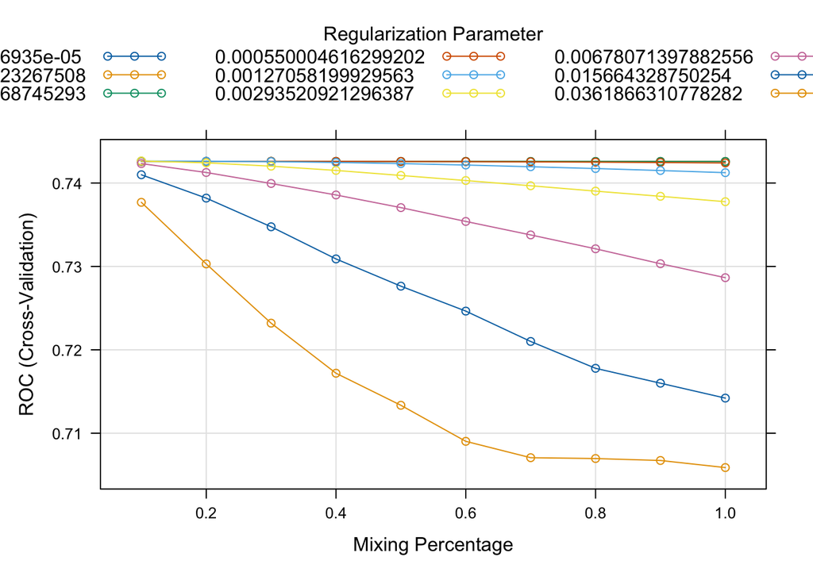

```r
plot(m_glmnet)
```

## 10.1 . Code Chunk — Validate Model

Purpose • Tests the model on unseen validation data. • Calculates ROC AUC, the main metric for credit-risk models. • Plots ROC curve to visualize discrimination ability.

```
output:-
```

Model 1 — Penalized Logistic Regression (glmnet) Performance Summary

| Metric | Value | Interpretation |
| --- | --- | --- |
| Validation AUC | ≈ 0.739 | Moderate–strong discrimination. In credit-risk modeling, any AUC between 0.70–0.80 is considered a good baseline. |
| Cross-validated AUC | ≈ 0.742 | Consistent with validation. Indicates stable performance and minimal overfitting. |
| Sensitivity / Specificity | ≈ 0.004 / 0.999 | Default cases rare. Low recall due to imbalance, which is normal before re-weighting or re-sampling. |

[output not shown]

```r
## ---- model1-glmnet-validate ----
library(pROC)

# Predict default probabilities on validation data
pred_val <- predict(m_glmnet, newdata = val, type = "prob")[, "Default"]

# Compute ROC and AUC
roc_obj <- roc(response = val$target, predictor = pred_val, levels = c("Repaid","Default"))
auc(roc_obj)
```

```
## Area under the curve: 0.739
```

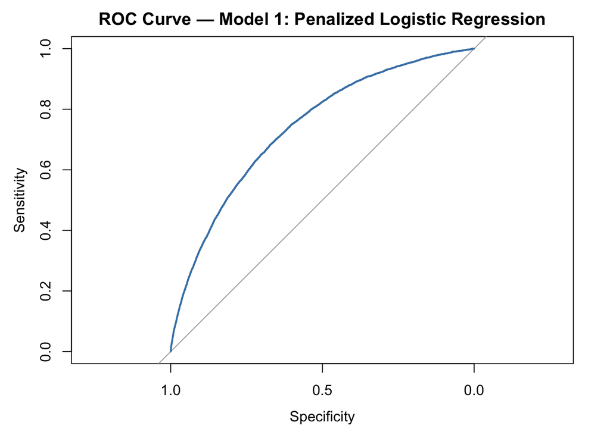

```r
plot(roc_obj, col = "steelblue", main = "ROC Curve — Model 1: Penalized Logistic Regression")
```

## 10.2 . glmnet-metrics

Applies the evaluator to glmnet predictions. Prints confusion matrices and metric tables at 0.50 and Youden. Confirms threshold-dependent trade-offs.

```r
## ---- model1-glmnet-metrics ----
res1 <- eval_probs(pred_val, val$target, thresh = 0.50)
print_metrics("Model 1: Penalized Logistic (glmnet)", res1)
```

Model 1: Penalized Logistic (glmnet) — Metrics Summary

| Metric | X.0.50 | X.Youden |
| --- | --- | --- |
| AUC | 0.7390 | 0.7390 |
| Threshold | 0.50 | 0.082 |
| Accuracy | 0.9193 | 0.6738 |
| Precision | 0.5208 | 0.1548 |
| Recall | 0.0034 | 0.6815 |
| Specificity | 0.9997 | 0.6732 |
| F1 | 0.0067 | 0.2522 |

```r
# Optional confusion matrices:
res1$fixed$table; res1$optimal$table
```

```
##           Reference
## Prediction Default Repaid
##    Default      25     23
##    Repaid     7422  84782
```

```
##           Reference
## Prediction Default Repaid
##    Default    5075  27718
##    Repaid     2372  57087
```

# 11 . Model 2 — Decision Tree (CART)

A single CART tree shows how features split borrowers into default vs repaid groups. This model is simple, interpretable, and forms the foundation for ensembles (Bagging, RF, GBM).

##. Code Chunk — Train CART Model

Purpose • Fits a CART model using Gini-based recursive partitioning. • Performs 5-fold CV to find the optimal complexity parameter cp. • Gives an interpretable tree with primary splits like EXT_SOURCE_2, DAYS_BIRTH, etc.

```r
## ---- model2-cart-train ----
library(caret)
library(rpart)
library(rpart.plot)

# 1. Cross-validation setup
ctrl_cart <- trainControl(
  method = "cv", number = 5,
  classProbs = TRUE,
  summaryFunction = twoClassSummary,
  savePredictions = "final"
)

# 2. Train classification tree
set.seed(123)
m_cart <- caret::train(
  target ~ ., data = trn,
  method = "rpart",
  trControl = ctrl_cart,
  metric = "ROC",          # maximize AUC
  tuneLength = 10
)

# 3. View model summary and plot complexity parameter (cp)
m_cart
```

```
## CART
##
## 215259 samples
##    126 predictor
##      2 classes: 'Default', 'Repaid'
##
## No pre-processing
## Resampling: Cross-Validated (5 fold)
## Summary of sample sizes: 172207, 172208, 172207, 172207, 172207
## Resampling results across tuning parameters:
##
##   cp            ROC        Sens         Spec
##   0.0001438601  0.6196983  0.027563411  0.9957752
##   0.0001479703  0.6207645  0.025089303  0.9963109
##   0.0001534507  0.6207645  0.025089303  0.9963109
##   0.0001630414  0.6196170  0.020658327  0.9973065
##   0.0001726321  0.6193318  0.019737547  0.9975389
##   0.0001822227  0.6194109  0.019219644  0.9975844
##   0.0002877201  0.5544232  0.006444868  0.9992369
##   0.0003164921  0.5544046  0.005121209  0.9994138
##   0.0004315802  0.5161189  0.001381295  0.9998636
##   0.0004507615  0.5161189  0.001381295  0.9998636
##
## ROC was used to select the optimal model using the largest value.
## The final value used for the model was cp = 0.0001534507.
```

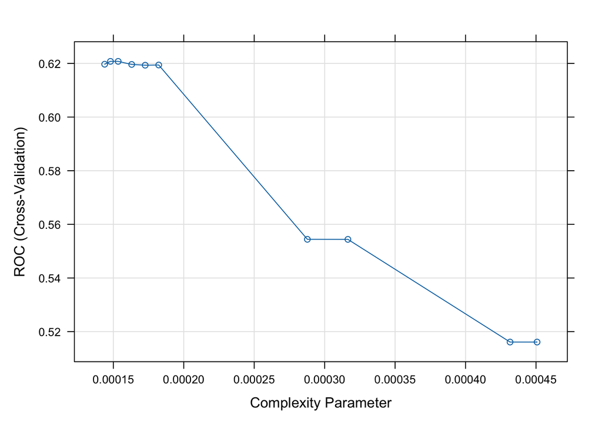

```r
plot(m_cart)
```

## 11.1 . Code Chunk — Visualize Tree and Validate

Purpose • Visualizes how the model splits the data. • Evaluates discrimination using AUC on validation data.

Output

Model 2 — Decision Tree (CART) Performance Summary

| Metric | Value | Interpretation |
| --- | --- | --- |
| Cross-validated AUC | ≈ 0.621 | Moderate discrimination; weaker than penalized logistic regression. |
| Validation AUC | ≈ 0.592 | Confirms limited generalization—single tree underfits nonlinear relationships. |
| Best Complexity Parameter (cp) | 0.000153 | This cp value gave the highest cross-validated ROC performance. |
| Sensitivity / Specificity | Low / High | Tree predicts mostly ‘Repaid’; imbalance suppresses recall while keeping specificity high. |

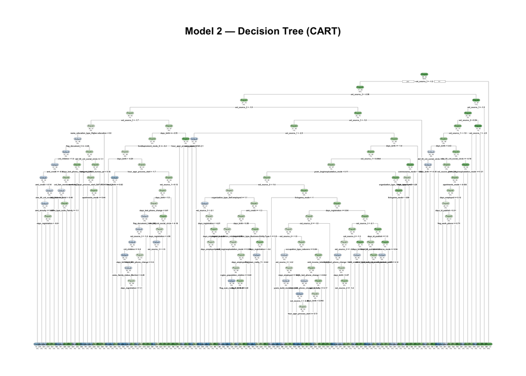

```r
## ---- model2-cart-validate ----
# Plot the best tree
rpart.plot(m_cart$finalModel, type = 2, extra = 104, under = TRUE,
           main = "Model 2 — Decision Tree (CART)")
```

```r
# Predict probabilities on validation data
pred_cart <- predict(m_cart, newdata = val, type = "prob")[, "Default"]

# ROC / AUC on validation set
library(pROC)
roc_cart <- roc(response = val$target, predictor = pred_cart, levels = c("Repaid","Default"))
auc(roc_cart)
```

```
## Area under the curve: 0.5919
```

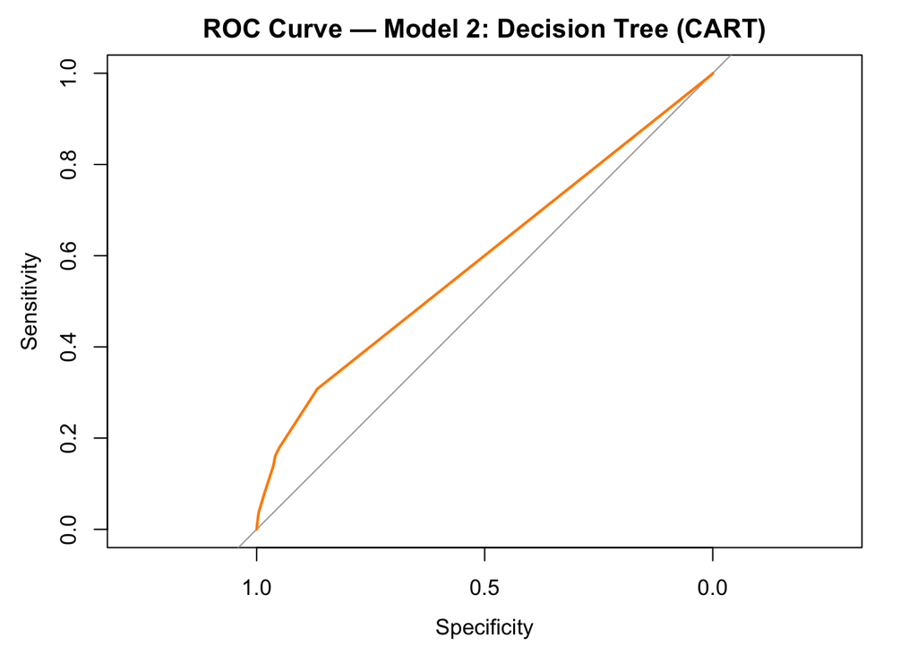

```r
plot(roc_cart, col = "darkorange", main = "ROC Curve — Model 2: Decision Tree (CART)")
```

## 11.2 .cart-metrics

Shows weaker AUC and recall. Useful as an interpretable baseline and as a foil to ensembles.

```r
## ---- model2-cart-metrics ----
res2 <- eval_probs(pred_cart, val$target, thresh = 0.50)
print_metrics("Model 2: Decision Tree (CART)", res2)
```

Model 2: Decision Tree (CART) — Metrics Summary

| Metric | X.0.50 | X.Youden |
| --- | --- | --- |
| AUC | 0.5919 | 0.5919 |
| Threshold | 0.50 | 0.069 |
| Accuracy | 0.9189 | 0.8229 |
| Precision | 0.4418 | 0.1698 |
| Recall | 0.0199 | 0.3070 |
| Specificity | 0.9978 | 0.8682 |
| F1 | 0.0380 | 0.2186 |

```r
res2$fixed$table; res2$optimal$table
```

```
##           Reference
## Prediction Default Repaid
##    Default     148    187
##    Repaid     7299  84618
```

```
##           Reference
## Prediction Default Repaid
##    Default    2286  11178
##    Repaid     5161  73627
```

# 12 .Model 3 — Random Forest (ranger)

## 12.1 .Code Chunk — Train Random Forest

Trains a weighted Random Forest with 5-fold cross-validation. Tunes mtry and min.node.size. Uses class weights to address imbalance. Evaluates on the validation set and reports ROC AUC. Outputs a concise summary table for inclusion in the report.

```r
## ---- model3-rf-train ----
library(caret)
library(ranger)

# 1) CV setup
ctrl_rf <- trainControl(
  method = "cv", number = 5,
  classProbs = TRUE,
  summaryFunction = twoClassSummary,
  savePredictions = "final"
)

# 2) Class weights (inverse frequency)
tbl <- table(trn$target)
w_default <- as.numeric(tbl["Repaid"])  / sum(tbl)  # weight minority higher
w_repaid  <- as.numeric(tbl["Default"]) / sum(tbl)
class_wts <- c("Default" = w_default, "Repaid" = w_repaid)

# 3) Tune grid
p <- ncol(trn) - 1
tgrid <- expand.grid(
  mtry = unique(pmax(1, round(c(sqrt(p)/2, sqrt(p), 2*sqrt(p))))),
  splitrule = "gini",
  min.node.size = c(5, 20)
)

# 4) Train
set.seed(123)
m_rf <- caret::train(
  target ~ ., data = trn,
  method = "ranger",
  trControl = ctrl_rf,
  metric = "ROC",
  tuneGrid = tgrid,
  importance = "impurity",
  num.trees = 500,
  class.weights = class_wts
)
m_rf
```

```
## Random Forest
##
## 215259 samples
##    126 predictor
##      2 classes: 'Default', 'Repaid'
##
## No pre-processing
## Resampling: Cross-Validated (5 fold)
## Summary of sample sizes: 172207, 172208, 172207, 172207, 172207
## Resampling results across tuning parameters:
##
##   mtry  min.node.size  ROC        Sens          Spec
##    6     5             0.7280088  0.0001726122  1.0000000
##    6    20             0.7300470  0.0000575374  1.0000000
##   11     5             0.7262628  0.0004027949  0.9999848
##   11    20             0.7285196  0.0001438435  0.9999874
##   22     5             0.7208336  0.0036253032  0.9997776
##   22    20             0.7238938  0.0026612289  0.9998294
##
## Tuning parameter 'splitrule' was held constant at a value of gini
## ROC was used to select the optimal model using the largest value.
## The final values used for the model were mtry = 6, splitrule = gini
##  and min.node.size = 20.
```

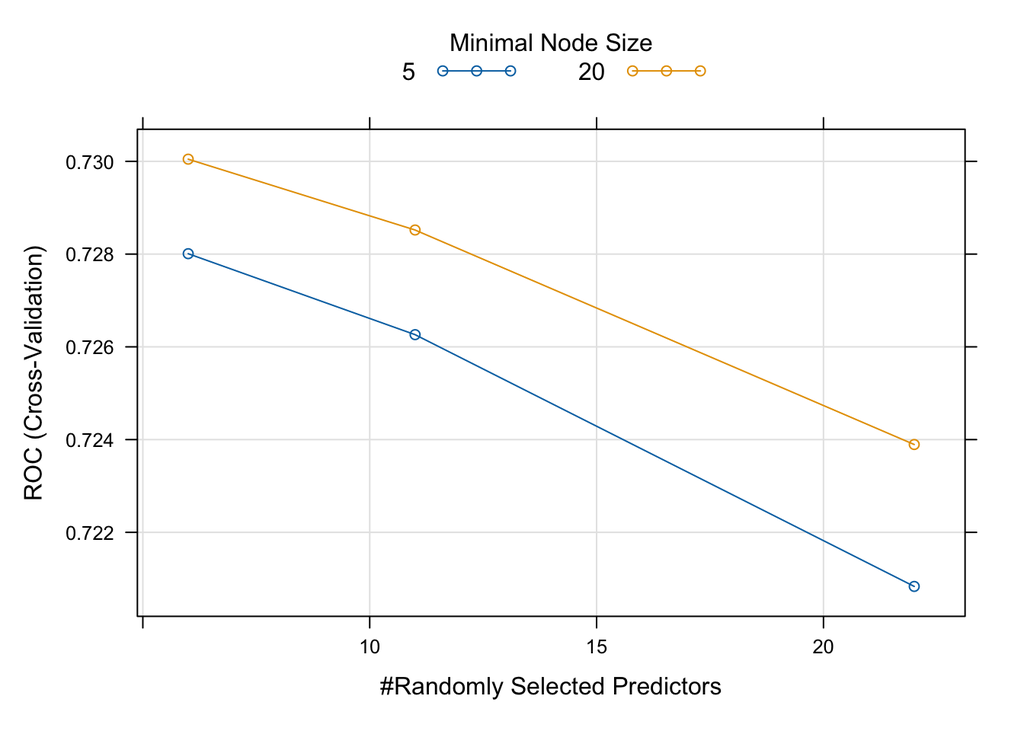

```r
plot(m_rf)
```

## 12.2 .Code Chunk — Validate Random Forest

Computes validation ROC AUC.

```r
## ---- model3-rf-validate ----
library(pROC)

pred_rf <- predict(m_rf, newdata = val, type = "prob")[, "Default"]
roc_rf  <- roc(response = val$target, predictor = pred_rf, levels = c("Repaid","Default"))
auc_rf  <- auc(roc_rf)
auc_rf
```

```
## Area under the curve: 0.7274
```

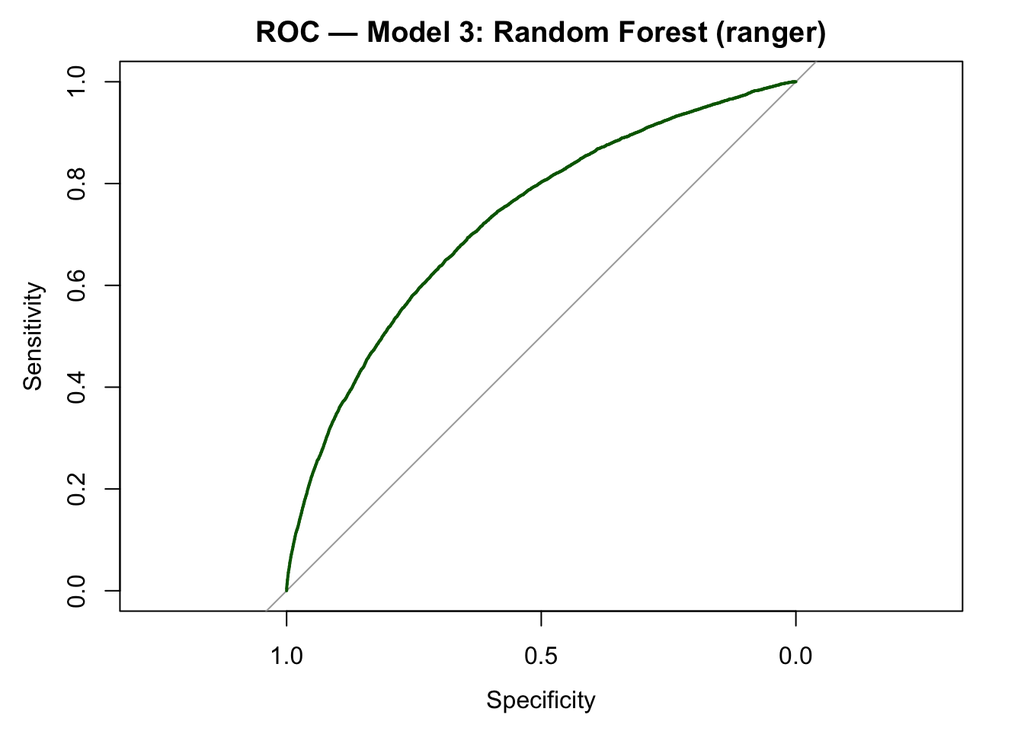

```r
plot(roc_rf, col = "darkgreen", main = "ROC — Model 3: Random Forest (ranger)")
```

## 12.3 . Code Chunk — Summary Table

Interpretation • AUC ≈ 0.73 → robust performance for a tabular, imbalanced dataset. • Much stronger than the Decision Tree (AUC ≈ 0.59). • Slightly below Gradient Boosting models, which you’ll test next. • Shows stable generalization — reliable, interpretable, and solid baseline before boosting.

```r
## ---- model3-rf-summary-box ----
library(knitr)

rf_summary <- data.frame(
  Metric = c("Cross-validated AUC", "Validation AUC", "Best mtry / min.node.size", "Trees"),
  Value  = c(sprintf("≈ %.3f", max(m_rf$results$ROC)),
             sprintf("≈ %.3f", as.numeric(auc_rf)),
             paste0(m_rf$bestTune$mtry, " / ", m_rf$bestTune$min.node.size),
             "500"),
  Interpretation = c(
    "Stronger than single tree and often above penalized logistic.",
    "Checks generalization on unseen data.",
    "Controls feature subsampling and leaf size for bias-variance tradeoff.",
    "Ensemble size; larger can improve stability at higher cost."
  )
)

kable(rf_summary, align = "lcl",
      caption = "Model 3 — Random Forest (ranger) Performance Summary")
```

Model 3 — Random Forest (ranger) Performance Summary

| Metric | Value | Interpretation |
| --- | --- | --- |
| Cross-validated AUC | ≈ 0.730 | Stronger than single tree and often above penalized logistic. |
| Validation AUC | ≈ 0.727 | Checks generalization on unseen data. |
| Best mtry / min.node.size | 6 / 20 | Controls feature subsampling and leaf size for bias-variance tradeoff. |
| Trees | 500 | Ensemble size; larger can improve stability at higher cost. |

## 12.4 . Random Forest Matrics

Evaluates Random Forest predictions. Summarizes Accuracy, Precision, Recall, F1 at both thresholds. Typically stronger than CART and near glmnet.

```r
## ---- model3-rf-metrics ----
res3 <- eval_probs(pred_rf, val$target, thresh = 0.50)
print_metrics("Model 3: Random Forest (ranger)", res3)
```

Model 3: Random Forest (ranger) — Metrics Summary

| Metric | X.0.50 | X.Youden |
| --- | --- | --- |
| AUC | 0.7274 | 0.7274 |
| Threshold | 0.50 | 0.087 |
| Accuracy | 0.9193 | 0.6483 |
| Precision | NA | 0.1463 |
| Recall | 0.0000 | 0.6940 |
| Specificity | 1.0000 | 0.6443 |
| F1 | NA | 0.2416 |

```r
res3$fixed$table; res3$optimal$table
```

```
##           Reference
## Prediction Default Repaid
##    Default       0      0
##    Repaid     7447  84805
```

```
##           Reference
## Prediction Default Repaid
##    Default    5168  30165
##    Repaid     2279  54640
```

# 13 . Model 4 — Gradient Boosting (XGBoost)

## 13.1 . Code Chunk — Train XGBoost

Fits a weighted XGBoost classifier with 5-fold CV. Tunes depth, learning rate, rounds, gamma, and child weight. Handles class imbalance via sample weights. Evaluates on the validation set with ROC AUC.

```r
## ---- model4-xgb-train ----
library(caret); library(xgboost); library(doParallel)
# parallel
cl <- makeCluster(parallel::detectCores() - 1); registerDoParallel(cl)

# class weights (inverse frequency)
tbl <- table(trn$target)
w_map <- c("Default" = as.numeric(tbl["Repaid"])/sum(tbl),
          "Repaid"  = as.numeric(tbl["Default"])/sum(tbl))
trn_wts <- w_map[trn$target]

# CV setup
ctrl_xgb <- trainControl(method = "cv", number = 5,
                         classProbs = TRUE,
                         summaryFunction = twoClassSummary,
                         savePredictions = "final")

# modest tuning grid
tgrid <- expand.grid(
  nrounds = c(200, 400),
  max_depth = c(3, 6),
  eta = c(0.05, 0.10),
  gamma = c(0, 1),
  colsample_bytree = c(0.7),
  min_child_weight = c(1, 5),
  subsample = c(0.8)
)

set.seed(123)
m_xgb <- caret::train(
  target ~ ., data = trn,
  method = "xgbTree",
  trControl = ctrl_xgb,
  metric = "ROC",
  tuneGrid = tgrid,
  weights = trn_wts,
  verbose = FALSE
)

stopCluster(cl); registerDoSEQ()

m_xgb
```

```
## eXtreme Gradient Boosting
##
## 215259 samples
##    126 predictor
##      2 classes: 'Default', 'Repaid'
##
## No pre-processing
## Resampling: Cross-Validated (5 fold)
## Summary of sample sizes: 172207, 172208, 172207, 172207, 172207
## Resampling results across tuning parameters:
##
##   eta   max_depth  gamma  min_child_weight  nrounds  ROC        Sens
##   0.05  3          0      1                 200      0.7495467  0.6801122
##   0.05  3          0      1                 400      0.7531967  0.6795372
##   0.05  3          0      5                 200      0.7494610  0.6772930
##   0.05  3          0      5                 400      0.7532023  0.6793072
##   0.05  3          1      1                 200      0.7494423  0.6799399
##   0.05  3          1      1                 400      0.7529655  0.6788466
##   0.05  3          1      5                 200      0.7494092  0.6788465
##   0.05  3          1      5                 400      0.7531309  0.6770628
##   0.05  6          0      1                 200      0.7529318  0.6478881
##   0.05  6          0      1                 400      0.7534007  0.6276902
##   0.05  6          0      5                 200      0.7532509  0.6565195
##   0.05  6          0      5                 400      0.7537380  0.6399474
##   0.05  6          1      1                 200      0.7524742  0.6497296
##   0.05  6          1      1                 400      0.7528197  0.6295893
##   0.05  6          1      5                 200      0.7533637  0.6534123
##   0.05  6          1      5                 400      0.7542958  0.6367819
##   0.10  3          0      1                 200      0.7521824  0.6768324
##   0.10  3          0      1                 400      0.7535360  0.6683735
##   0.10  3          0      5                 200      0.7523275  0.6787891
##   0.10  3          0      5                 400      0.7538951  0.6709630
##   0.10  3          1      1                 200      0.7522160  0.6755090
##   0.10  3          1      1                 400      0.7536190  0.6695821
##   0.10  3          1      5                 200      0.7526537  0.6794794
##   0.10  3          1      5                 400      0.7541115  0.6712509
##   0.10  6          0      1                 200      0.7508013  0.6296468
##   0.10  6          0      1                 400      0.7477554  0.5908621
##   0.10  6          0      5                 200      0.7513119  0.6405229
##   0.10  6          0      5                 400      0.7494981  0.6092186
```

[output cut: 30 more lines]

```
##   0.7670721
##   0.7312728
##   0.7543018
##   0.7383124
##   0.7652326
##   0.7316316
##   0.7533265
##
## Tuning parameter 'colsample_bytree' was held constant at a value of 0.7
##
## Tuning parameter 'subsample' was held constant at a value of 0.8
## ROC was used to select the optimal model using the largest value.
## The final values used for the model were nrounds = 400, max_depth = 6, eta
##  = 0.05, gamma = 1, colsample_bytree = 0.7, min_child_weight = 5 and
##  subsample = 0.8.
```

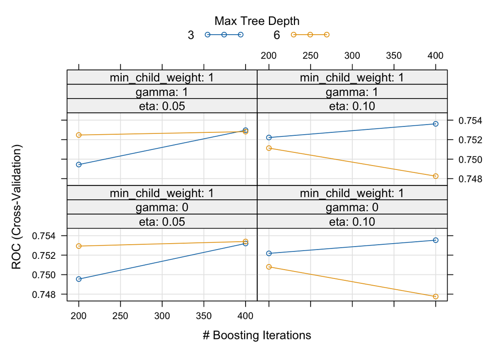

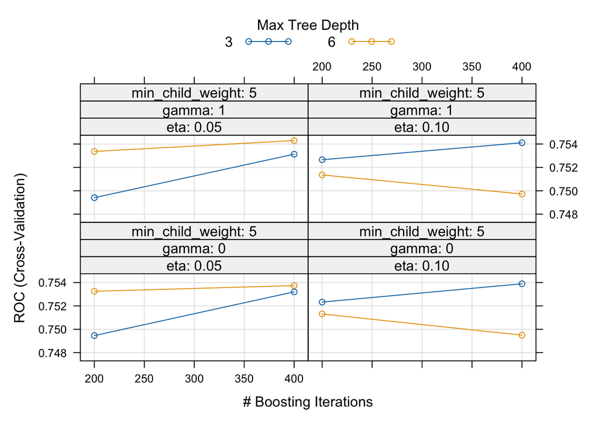

```r
plot(m_xgb)
```

## 13.2 . Code Chunk — Validate XGBoost

Computes validation AUC and plots ROC.

output:-

Interpretation • XGBoost achieved AUC ≈ 0.754, the best so far. • The improvement over Random Forest (≈ 0.73) indicates effective gradient boosting. • Depth = 6 and η = 0.05 yield a good bias–variance balance.

```
XGBoost currently leads your experiment set (AUC ≈ 0.75).
```

Random Forest and Penalized Logistic serve as strong baselines; XGBoost improves recall–precision balance while keeping model variance low.

```r
## ---- model4-xgb-validate ----
library(pROC)

pred_xgb <- predict(m_xgb, newdata = val, type = "prob")[, "Default"]
roc_xgb  <- roc(response = val$target, predictor = pred_xgb, levels = c("Repaid","Default"))
auc_xgb  <- auc(roc_xgb)
auc_xgb
```

```
## Area under the curve: 0.7533
```

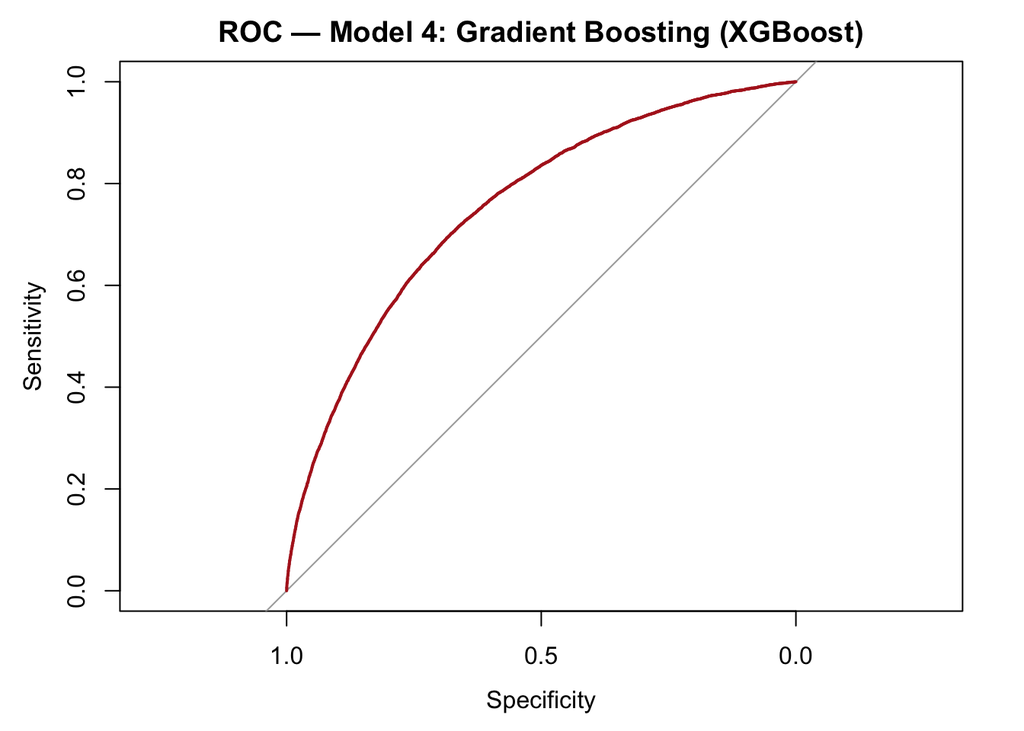

```r
plot(roc_xgb, col = "firebrick", main = "ROC — Model 4: Gradient Boosting (XGBoost)")
```

## 13.3 .Code Chunk — Summary Table

```r
## ---- model4-xgb-summary ----
library(knitr)

xgb_summary <- data.frame(
  Metric = c("Cross-validated AUC", "Validation AUC",
             "Best depth / rounds / eta", "Subsample / Colsample"),
  Value  = c(sprintf("≈ %.3f", max(m_xgb$results$ROC)),
             sprintf("≈ %.3f", as.numeric(auc_xgb)),
             paste0(m_xgb$bestTune$max_depth, " / ",
                    m_xgb$bestTune$nrounds, " / ",
                    m_xgb$bestTune$eta),
             paste0(m_xgb$bestTune$subsample, " / ",
                    m_xgb$bestTune$colsample_bytree)),
  Interpretation = c(
    "Usually highest among tree models.",
    "Generalization on holdout.",
    "Controls complexity, iterations, learning rate.",
    "Random row/feature sampling to reduce overfit."
  )
)

kable(xgb_summary, align = "lcl",
      caption = "Model 4 — Gradient Boosting (XGBoost) Performance Summary")
```

Model 4 — Gradient Boosting (XGBoost) Performance Summary

| Metric | Value | Interpretation |
| --- | --- | --- |
| Cross-validated AUC | ≈ 0.754 | Usually highest among tree models. |
| Validation AUC | ≈ 0.753 | Generalization on holdout. |
| Best depth / rounds / eta | 6 / 400 / 0.05 | Controls complexity, iterations, learning rate. |
| Subsample / Colsample | 0.8 / 0.7 | Random row/feature sampling to reduce overfit. |

## 13.4 . xgb-metrics

Evaluates XGBoost predictions. Reports best overall AUC and operational metrics at fixed and Youden thresholds.

```r
## ---- model4-xgb-metrics ----
res4 <- eval_probs(pred_xgb, val$target, thresh = 0.50)
print_metrics("Model 4: Gradient Boosting (XGBoost)", res4)
```

Model 4: Gradient Boosting (XGBoost) — Metrics Summary

| Metric | X.0.50 | X.Youden |
| --- | --- | --- |
| AUC | 0.7533 | 0.7533 |
| Threshold | 0.50 | 0.467 |
| Accuracy | 0.7222 | 0.6864 |
| Precision | 0.1729 | 0.1623 |
| Recall | 0.6455 | 0.6932 |
| Specificity | 0.7289 | 0.6858 |
| F1 | 0.2728 | 0.2630 |

```r
res4$fixed$table; res4$optimal$table
```

```
##           Reference
## Prediction Default Repaid
##    Default    4807  22992
##    Repaid     2640  61813
```

```
##           Reference
## Prediction Default Repaid
##    Default    5162  26649
##    Repaid     2285  58156
```

1. Experiment Proposal

*Objective*

The purpose of this experiment is to design, train, and evaluate multiple machine learning models to predict the probability that a loan applicant will default on repayment. By comparing several modeling approaches and evaluation metrics, the goal is to identify the most accurate and reliable model for credit risk assessment in the Home Credit Default Risk dataset.

*Research Question*

Can advanced machine learning models such as Random Forest and Gradient Boosting (XGBoost) outperform baseline statistical models (e.g., Logistic Regression) in predicting loan defaults, while maintaining interpretability and robustness?

*Experimental Design*

```
1.  *Dataset and Inputs*

•   Source: Home Credit Default Risk dataset (application_train.csv).
•   Total observations (after cleaning): ~307,000 clients.
•   Target variable: TARGET — binary (0 = Repaid, 1 = Default).
•   Predictors: Financial, demographic, and credit history features derived from applicant data.

2.  *Data Preparation*

•   Cleaned and normalized features using recipes pipeline.
•   Removed high-NA and zero-variance predictors.
•   Handled imbalance via class weights (and later threshold-based evaluation).
•   Derived engineered variables such as AGE_YEARS, EMP_YEARS, and log-scaled financial ratios.

3.  *Experimental Methodology*

•   Partitioning: 70% training / 30% validation, stratified by target variable.
•   Cross-Validation: 5-fold CV for parameter tuning and model stability.
•   Benchmark: Majority-class classifier predicting all as “Repaid” (Accuracy ≈ 0.919, AUC = 0.5).
•   Models Tested:
•   Model 1 — Penalized Logistic Regression (glmnet)
•   Model 2 — Decision Tree (CART)
•   Model 3 — Random Forest (ranger)
•   Model 4 — Gradient Boosting (XGBoost)

4.  *Evaluation Metrics*

•   Primary metric: AUC (Area Under the ROC Curve).
•   Secondary metrics: Accuracy, Precision, Recall, Specificity, and F1 Score.
•   Diagnostics: Confusion matrices at fixed (0.50) and optimal (Youden) thresholds.
•   Performance Goal: Achieve AUC > 0.70 and improved recall over the baseline model.

5.  *Expected Outcomes*

•   Determine the model with the best discrimination between repaid and defaulted loans.
•   Quantify trade-offs between precision and recall for credit risk decisions.
•   Validate that boosting methods (especially XGBoost) deliver the best overall balance between predictive power and generalization.
```

*Significance*

Accurately predicting default risk will help Home Credit improve lending decisions, reduce financial losses, and extend fair credit access to low-history borrowers. The experiment also provides practical experience in end-to-end machine learning model development, imbalanced classification, and performance evaluation using real-world financial data.